# Fysieke gezondheid en wiskundige geletterdheid

Analyse alcohol consumptie en grades Math4IT

Ilya Mikhaylov

Uitlezen data en maken van een mini dataframe en verwijderen NA waarden voor regressie analyse

```r
data <- read_csv('../data/npe-1920-wiskundige-geletterdheid.csv')
usedData <- data.frame(AlcoholConsumptions=data$AlcoholConsumption,
                       GradesMath4IT=data$GradeMath4IT,
                       Gender=data$Gender)
usedDataWithoutNA <- na.omit(usedData)
glimpse(usedDataWithoutNA)
```

```
## Rows: 195
## Columns: 3
## $ AlcoholConsumptions <dbl> 6, 3, 0, 0, 10, 0, 0, 0, 0, 2, 3, 5, 1, 15, 1, ...
## $ GradesMath4IT       <dbl> 0, 12, 10, 14, 14, 10, 13, 10, 14, 10, 11, 10, ...
## $ Gender              <chr> "Mannelijk", "Mannelijk", "Mannelijk", "Manneli...
```

## Regressie-analyse niet opgesplitst in geslacht `AlcoholConsumption` vs `GradeMath4IT`

Is er een verband tussen aantal standaardglazen alcohol (`AlcoholConsumption`) en het examencijfer voor Math4IT (`GradeMath4IT`)

### Visualisatie van de dataset

De onafhankelijke variabele (`AlcoholConsumption`) wordt afgebeeld op de X-as, de afhankelijke (`GradeMath4IT`) op de Y-as. We tekenen ook de regressierechte:

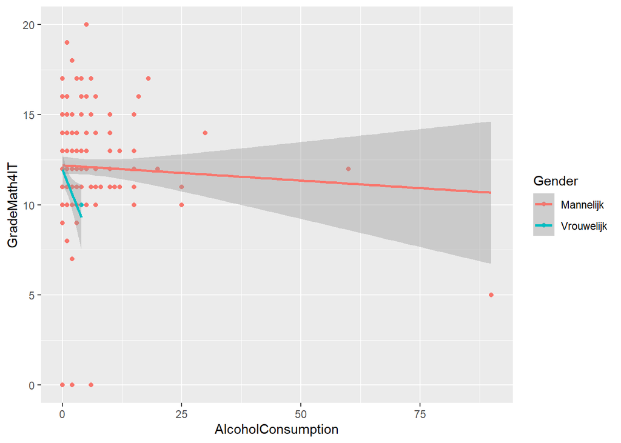

```r
ggplot(data = data, mapping = aes(x = AlcoholConsumption, y = GradeMath4IT, col = Gender)) +
  geom_point() +
  geom_smooth(method = "lm", formula = y ~ x)
```

### Regressie analyse

```r
#                                       afh                           onafh
regr_alcoholmath <- lm(usedDataWithoutNA$GradesMath4IT ~ usedDataWithoutNA$AlcoholConsumptions)
regr_alcoholmath
```

```
##
## Call:
## lm(formula = usedDataWithoutNA$GradesMath4IT ~ usedDataWithoutNA$AlcoholConsumptions)
##
## Coefficients:
##                           (Intercept)  usedDataWithoutNA$AlcoholConsumptions
##                              12.12877                               -0.01488
```

### Correlatie en determinatie

```r
correlatieCoefficient <- cor(x = usedDataWithoutNA$AlcoholConsumptions, y = usedDataWithoutNA$GradesMath4IT)
determinatieCoefficient <- correlatieCoefficient^2
correlatieCoefficient
```

```
## [1] -0.04721834
```

```r
determinatieCoefficient
```

```
## [1] 0.002229572
```

De correlatiecoëfficiënt is hier -0.047, duidend op een zeer zwak en dalend verband. Ongeveer 0.2% van de variantie in de observaties wordt verklaard door de regressierechte.

## Mannelijk

```r
mannelijk <- usedDataWithoutNA[usedDataWithoutNA$Gender == "Mannelijk",]
regr_mannelijk <- lm(mannelijk$GradesMath4IT ~ mannelijk$AlcoholConsumptions)
regr_mannelijk
```

```
##
## Call:
## lm(formula = mannelijk$GradesMath4IT ~ mannelijk$AlcoholConsumptions)
##
## Coefficients:
##                   (Intercept)  mannelijk$AlcoholConsumptions
##                      12.20111                       -0.01684
```

```r
correlatieCoefficient_mannen <- cor(x = mannelijk$GradesMath4IT, y = mannelijk$AlcoholConsumptions)
determinatieCoefficient_mannen <- cor(x = mannelijk$GradesMath4IT, y = mannelijk$AlcoholConsumptions)^2
correlatieCoefficient_mannen
```

```
## [1] -0.05364059
```

```r
determinatieCoefficient_mannen
```

```
## [1] 0.002877313
```

De correlatiecoëfficiënt is hier -0.053, duidend op een zeer zwak en dalend verband. Ongeveer 0.2% van de variantie in de observaties wordt verklaard door de regressierechte.

## Vrouwelijk

```r
vrouwelijk <- usedDataWithoutNA[usedDataWithoutNA$Gender == "Vrouwelijk",]
regr_vrouwelijk <- lm(vrouwelijk$GradesMath4IT ~ vrouwelijk$AlcoholConsumptions)
regr_vrouwelijk
```

```
##
## Call:
## lm(formula = vrouwelijk$GradesMath4IT ~ vrouwelijk$AlcoholConsumptions)
##
## Coefficients:
##                    (Intercept)  vrouwelijk$AlcoholConsumptions
##                        11.9455                         -0.6636
```

```r
correlatieCoefficient_vrouwen <- cor(x = vrouwelijk$GradesMath4IT, y = vrouwelijk$AlcoholConsumptions)
determinatieCoefficient_vrouwen <- cor(x = vrouwelijk$GradesMath4IT, y = vrouwelijk$AlcoholConsumptions)^2
correlatieCoefficient_vrouwen
```

```
## [1] -0.6058143
```

```r
determinatieCoefficient_vrouwen
```

```
## [1] 0.367011
```